# Untitled

김호성

2020 10 28

## EDA

```r
dat=read.csv('NPB.final.csv',row.names = 1)
attach(dat)

summary(dat) #각종 기술 통계
```

```
##     League              Team                 Yr             G
##  Length:987         Length:987         Min.   :1936   Min.   : 26.0
##  Class :character   Class :character   1st Qu.:1959   1st Qu.:130.0
##  Mode  :character   Mode  :character   Median :1979   Median :130.0
##                                        Mean   :1979   Mean   :127.7
##                                        3rd Qu.:2000   3rd Qu.:140.0
##                                        Max.   :2020   Max.   :154.0
##
##        W              L                D               G_h1
##  Min.   : 5.0   Min.   :  6.00   Min.   : 0.000   Min.   : 26.0
##  1st Qu.:54.0   1st Qu.: 54.00   1st Qu.: 2.000   1st Qu.:130.0
##  Median :64.0   Median : 63.00   Median : 4.000   Median :130.0
##  Mean   :61.6   Mean   : 61.63   Mean   : 4.438   Mean   :127.7
##  3rd Qu.:72.0   3rd Qu.: 71.00   3rd Qu.: 6.000   3rd Qu.:140.0
##  Max.   :99.0   Max.   :103.00   Max.   :19.000   Max.   :154.0
##
##      PA_h1          AB_h1           R_h1            H_h1          X2B_h1
##  Min.   :1029   Min.   : 881   Min.   : 81.0   Min.   : 167   Min.   : 21.0
##  1st Qu.:4758   1st Qu.:4268   1st Qu.:444.5   1st Qu.:1035   1st Qu.:155.0
##  Median :4943   Median :4379   Median :526.0   Median :1132   Median :178.0
##  Mean   :4798   Mean   :4267   Mean   :508.2   Mean   :1078   Mean   :173.3
##  3rd Qu.:5256   3rd Qu.:4702   3rd Qu.:593.0   3rd Qu.:1205   3rd Qu.:203.0
##  Max.   :5825   Max.   :5209   Max.   :908.0   Max.   :1461   Max.   :290.0
##
##      X3B_h1          HR_h1           SB_h1           CS_h1
##  Min.   : 2.00   Min.   :  0.0   Min.   : 25.0   Min.   : 10.00
##  1st Qu.:17.00   1st Qu.: 80.0   1st Qu.: 63.0   1st Qu.: 35.00
##  Median :21.00   Median :110.0   Median : 84.0   Median : 46.00
##  Mean   :23.18   Mean   :105.9   Mean   : 91.2   Mean   : 47.38
##  3rd Qu.:28.00   3rd Qu.:140.0   3rd Qu.:112.0   3rd Qu.: 57.00
##  Max.   :66.00   Max.   :259.0   Max.   :277.0   Max.   :179.00
##                                  NA's   :1       NA's   :66
##     BBHBP_h1         AVG_h1           OBP_h1           SLG_h1
##  Min.   :101.0   Min.   :0.1800   Min.   :0.2480   Min.   :0.2170
##  1st Qu.:377.0   1st Qu.:0.2410   1st Qu.:0.3030   1st Qu.:0.3500
##  Median :431.0   Median :0.2540   Median :0.3190   Median :0.3790
##  Mean   :426.4   Mean   :0.2509   Mean   :0.3169   Mean   :0.3738
##  3rd Qu.:488.0   3rd Qu.:0.2650   3rd Qu.:0.3330   3rd Qu.:0.4080
##  Max.   :662.0   Max.   :0.2970   Max.   :0.3770   Max.   :0.5010
##  NA's   :135
```

[output cut: 25 more lines]

```
##  Mode:logical   Mode:logical   Mode:logical   Mode:logical   Mode:logical
##  NA's:987       NA's:987       NA's:987       NA's:987       NA's:987
##
##
##
##
##
##  bwRCplus_h      bWAR_h        bFIPplus_p      bWAR_p
##  Mode:logical   Mode:logical   Mode:logical   Mode:logical
##  NA's:987       NA's:987       NA's:987       NA's:987
##
##
##
##
##
```

최소값들이 특이할 정도로 작은 값이 많이 나오고 있다. 전체적인 경기수가 적었던 초창기 시즌들 때문인 것으로 보인다.

계획 과정에서 역사가 깊은 야구데이터 중 과거데이터와 현재 데이터가 얼마나 차이날 것인가? 언제부터가 현대적인 의미의 야구로 유의미한 자료인가? 하는 문제들을 찾아보기 위해 년단위로 plot을 그려보겠다.흔히 말하는 야구의 패러다임 변화를 볼 때 주로 찾는경기당 득점이나 홈런 수의 변화 양상을 보겠다.

```r
season=c(1936,1937,1937.5,1938,1938.5,seq(1939,1944),seq(1946,2020))
league_total_hr_per_g=c()
league_total_R_per_g=c()
for (i in season){league_total_hr=sum(subset(dat,select = HR_h1,subset = Yr==i))
league_total_g=sum(subset(dat,select = G,subset = Yr==i))
league_total_hr_per_g=append(league_total_hr_per_g,(league_total_hr/league_total_g))
}
for (i in season){league_total_R=sum(subset(dat,select = R_h1,subset = Yr==i))
league_total_g=sum(subset(dat,select = G,subset = Yr==i))
league_total_R_per_g=append(league_total_R_per_g,(league_total_R/league_total_g))
}
league_total_hr_per_g
```

```
##  [1] 0.09090909 0.10491071 0.27692308 0.21785714 0.30555556 0.18055556
##  [7] 0.11300640 0.14705882 0.12857143 0.10863095 0.10952381 0.25119048
## [13] 0.25210084 0.34910714 0.79704797 0.80010277 0.58064516 0.52519733
## [19] 0.50310559 0.49868628 0.47523220 0.43936382 0.52288732 0.55256410
## [25] 0.60213033 0.63762626 0.63395062 0.64205257 0.80459770 0.82183908
## [31] 0.76309524 0.75962733 0.85027726 0.96592317 0.97693786 0.93782051
## [37] 0.97884615 1.02756410 0.92564103 0.96662388 0.92948718 1.04230769
## [43] 1.12115385 1.04743590 1.20448718 1.31089744 1.03717949 0.97756410
## [49] 1.16474359 1.18910256 1.28012821 1.16410256 1.08076923 0.95769231
## [55] 1.02564103 1.07648184 0.95977011 0.92907348 0.88205453 0.89891235
## [61] 0.90582960 0.95201596 0.88854680 0.86538462 0.96672828 0.96736453
## [67] 1.07325789 1.00892857 1.18273810 1.24381188 1.03250591 0.85874704
## [73] 0.84490741 0.85648148 0.88773148 0.92881944 0.54340278 0.50983796
## [79] 0.75868056 0.78761574 0.70979021 0.78146853 0.87412587 0.97960373
## [85] 0.98368298 0.91849530
```

```r
league_total_R_per_g
```

```
##  [1] 4.196970 4.191964 4.469231 4.146429 3.977778 3.531250 3.076759 2.648529
##  [9] 2.586905 2.632440 3.385714 4.332143 3.246849 3.525893 4.812731 4.842754
## [17] 4.367608 4.134183 3.886335 3.675775 3.470588 3.184891 3.314554 3.321795
## [25] 3.431078 3.431187 3.514815 3.474969 3.638506 3.723563 3.379167 3.327950
## [33] 3.561306 3.735440 3.659193 3.617949 3.735897 3.981410 3.694872 3.874198
## [41] 3.825000 4.010256 4.241667 4.383333 4.529487 4.555769 4.237179 3.995513
## [49] 4.537179 4.614744 4.928205 4.228846 4.135897 3.960897 4.266667 4.475462
## [57] 4.145594 4.120767 3.906151 4.316699 4.003844 4.271276 4.264163 4.224566
## [65] 4.346888 4.520320 4.425253 3.974405 4.769048 4.991337 4.428487 4.025414
## [73] 4.027778 4.135417 4.127315 4.387731 3.277199 3.256366 3.990162 4.115741
## [81] 3.761655 4.006993 3.996503 4.317599 4.256993 4.154389
```

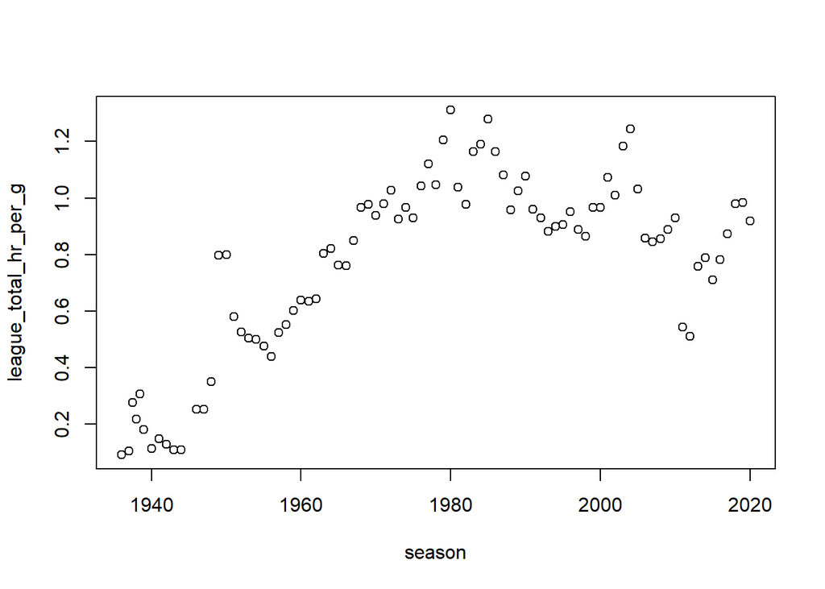

```r
plot(season,league_total_hr_per_g)
```

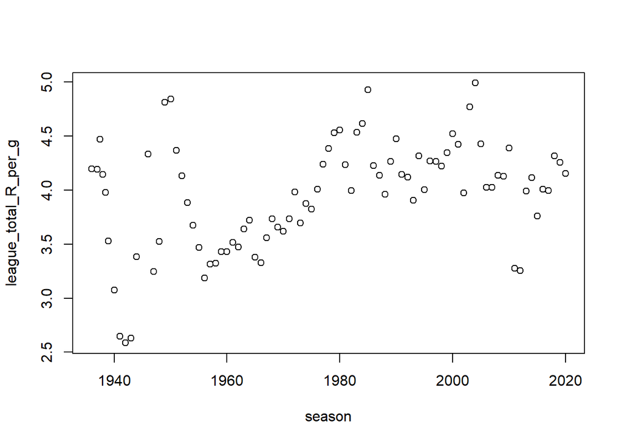

```r
plot(season,league_total_R_per_g)
```

추가적으로 홈런과 득점은 개형만 보면 상당히 비슷하게 따라가는 듯 보이나 득점의 편차가 훤씬 커서 정확하지 않다.

```r
dat2=subset(dat,subset = Yr>=1950)
summary(dat2)
```

```
##     League              Team                 Yr             G
##  Length:867         Length:867         Min.   :1950   Min.   : 96
##  Class :character   Class :character   1st Qu.:1966   1st Qu.:130
##  Mode  :character   Mode  :character   Median :1984   Median :131
##                                        Mean   :1984   Mean   :134
##                                        3rd Qu.:2002   3rd Qu.:140
##                                        Max.   :2020   Max.   :154
##
##        W               L                D               G_h1         PA_h1
##  Min.   :29.00   Min.   : 24.00   Min.   : 0.000   Min.   : 96   Min.   :3537
##  1st Qu.:57.00   1st Qu.: 57.00   1st Qu.: 2.000   1st Qu.:130   1st Qu.:4819
##  Median :65.00   Median : 65.00   Median : 4.000   Median :131   Median :4981
##  Mean   :64.63   Mean   : 64.66   Mean   : 4.667   Mean   :134   Mean   :5029
##  3rd Qu.:73.00   3rd Qu.: 72.00   3rd Qu.: 6.000   3rd Qu.:140   3rd Qu.:5306
##  Max.   :99.00   Max.   :103.00   Max.   :19.000   Max.   :154   Max.   :5825
##
##      AB_h1           R_h1            H_h1          X2B_h1          X3B_h1
##  Min.   :3201   Min.   :290.0   Min.   : 713   Min.   :100.0   Min.   : 5.00
##  1st Qu.:4308   1st Qu.:476.0   1st Qu.:1076   1st Qu.:163.0   1st Qu.:17.00
##  Median :4413   Median :538.0   Median :1145   Median :183.0   Median :21.00
##  Mean   :4477   Mean   :537.8   Mean   :1141   Mean   :185.1   Mean   :22.91
##  3rd Qu.:4727   3rd Qu.:597.5   3rd Qu.:1214   3rd Qu.:207.0   3rd Qu.:28.00
##  Max.   :5209   Max.   :908.0   Max.   :1461   Max.   :290.0   Max.   :66.00
##
##      HR_h1           SB_h1            CS_h1           BBHBP_h1
##  Min.   : 27.0   Min.   : 25.00   Min.   : 12.00   Min.   :256.0
##  1st Qu.: 90.0   1st Qu.: 65.00   1st Qu.: 35.00   1st Qu.:388.0
##  Median :116.0   Median : 84.00   Median : 46.00   Median :441.0
##  Mean   :117.6   Mean   : 91.79   Mean   : 47.04   Mean   :441.5
##  3rd Qu.:143.0   3rd Qu.:112.00   3rd Qu.: 56.00   3rd Qu.:495.0
##  Max.   :259.0   Max.   :277.00   Max.   :179.00   Max.   :662.0
##                  NA's   :1                         NA's   :135
##      AVG_h1           OBP_h1           SLG_h1       wOBA_h1
##  Min.   :0.2010   Min.   :0.2480   Min.   :0.2810   Mode:logical
##  1st Qu.:0.2450   1st Qu.:0.3050   1st Qu.:0.3600   NA's:867
##  Median :0.2560   Median :0.3200   Median :0.3850
##  Mean   :0.2546   Mean   :0.3175   Mean   :0.3849
##  3rd Qu.:0.2660   3rd Qu.:0.3330   3rd Qu.:0.4110
##  Max.   :0.2970   Max.   :0.3690   Max.   :0.5010
##
```

[output cut: 25 more lines]

```
##  Mode:logical   Mode:logical   Mode:logical   Mode:logical   Mode:logical
##  NA's:867       NA's:867       NA's:867       NA's:867       NA's:867
##
##
##
##
##
##   bWAR_h        bFIPplus_p      bWAR_p
##  Mode:logical   Mode:logical   Mode:logical
##  NA's:867       NA's:867       NA's:867
##
##
##
##
##
```

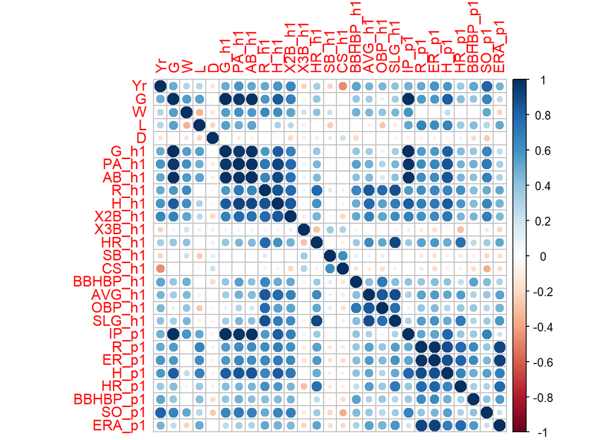

```r
library(corrplot)
mat=dat[,c(seq(3,21),seq(26,29),seq(32,35))]
mat=na.omit(mat)
mat_cor=cor(mat)
corrplot(mat_cor,method='circle')
```

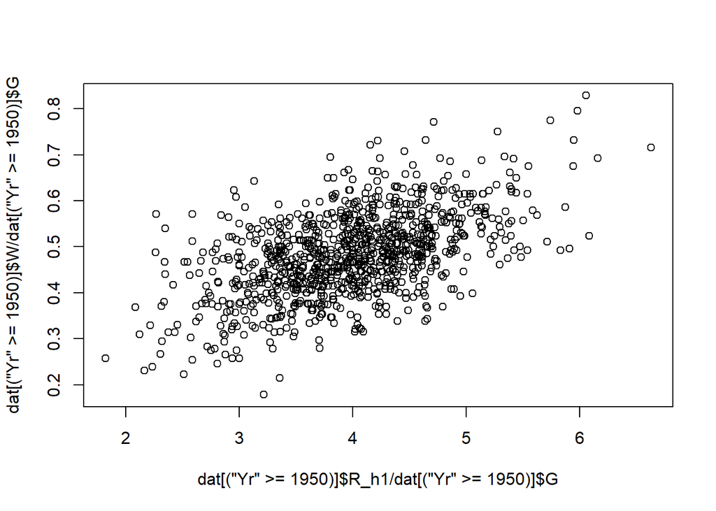

```r
plot(dat[('Yr'>=1950)]$R_h1/dat[('Yr'>=1950)]$G,dat[('Yr'>=1950)]$W/dat[('Yr'>=1950)]$G)
```